# Week8

Kian Bigović Villi

2023-05-02

```r
suppressPackageStartupMessages({
  library(epiwraps)
  library(motifmatchr)
  library(MotifDb)
  library(universalmotif)
  library(sechm)
  library(BiocParallel)
  library(ggplot2)
  library(chromVAR) # for motif accessibility estimation
  library(SummarizedExperiment) # data structure
  library(limma) # for statistical analysis
})
```

```
## See system.file("LICENSE", package="MotifDb") for use restrictions.
```

```r
register(SerialParam())
```

```r
#Download the SE data
options(timeout=6000)
download.file("https://ethz-ins.org/content/mouse_mm38_hippocampus.peakCounts.SE.rds",
              "mouse_hipopocampus_SE.rds", mode="wb")
se <- readRDS("mouse_hipopocampus_SE.rds")
se
```

```
## class: RangedSummarizedExperiment
## dim: 20660 12
## metadata(0):
## assays(1): counts
## rownames: NULL
## rowData names(0):
## colnames(12): Control_female_GSM6041841.bam
##   Control_female_GSM6041842.bam ... FSS_male_GSM6041857.bam
##   FSS_male_GSM6041858.bam
## colData names(1): depth
```

```r
#Define the sex and condition of the data
colData(se)$sex <- c(rep("Female",3), rep("Male",3),
                            rep("Female",3), rep("Male",3))
colData(se)$condition <- c(rep("Control",6), rep("FSS",6))
```

```r
#To add the GC bias, load the genome
genome <- BSgenome.Mmusculus.UCSC.mm10::BSgenome.Mmusculus.UCSC.mm10
#Change the naming convention to the UCSC one
seqlevelsStyle(se) = "UCSC"
#Add the bias
se <- suppressWarnings(chromVAR::addGCBias(se, genome=genome))
```

```r
#To do the motif analysis we need a set of motifs to use
motifs <- query(MotifDb, c("Mmusculus", "HOCOMOCOv10"))
motifs <- do.call(TFBSTools::PWMatrixList, setNames(
           universalmotif::convert_motifs(motifs, class="TFBSTools-PWMatrix"),
           mcols(motifs)$providerName))
#Find the peaks containing the genomes
moi <- suppressWarnings(motifmatchr::matchMotifs(motifs, subject=se, genome=genome))
moi
```

```
## class: RangedSummarizedExperiment
## dim: 20660 426
## metadata(0):
## assays(1): motifMatches
## rownames: NULL
## rowData names(1): bias
## colnames(426): AHR_MOUSE.H10MO.B AIRE_MOUSE.H10MO.C ...
##   ZN148_MOUSE.H10MO.D ZN423_MOUSE.H10MO.D
## colData names(1): name
```

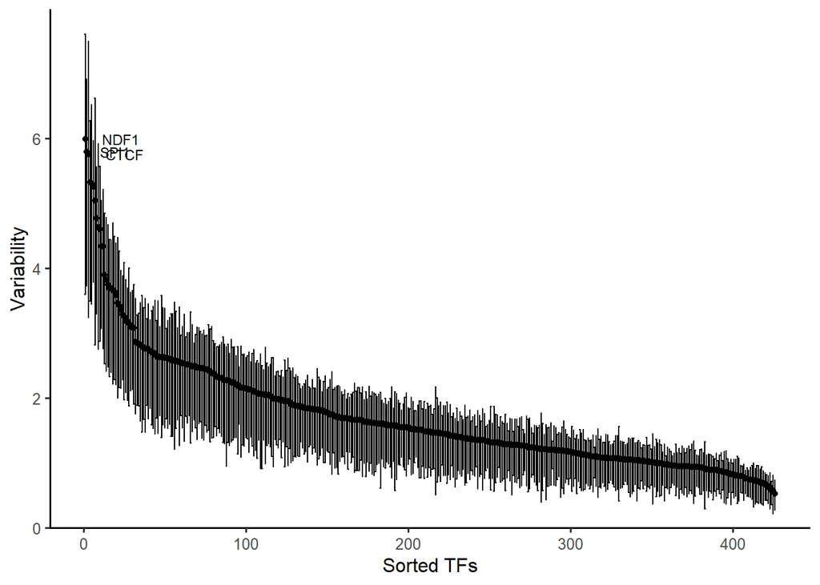

```r
#Compute the deviations in accessibility for each set of peaks
dev <- chromVAR::computeDeviations(object = se, annotations=moi,
                                   background_peaks=getBackgroundPeaks(se, niterations=1000))

#Compute the variablility of the deviations
variability <- computeVariability(dev)
#Plot the ranked variablities
plotVariability(variability)
```

From the plot its possible to see that the data contains generally moderate variability for all TFs. With there being a group of around top 40 with high variability, and the rest following a slow downwards trend.

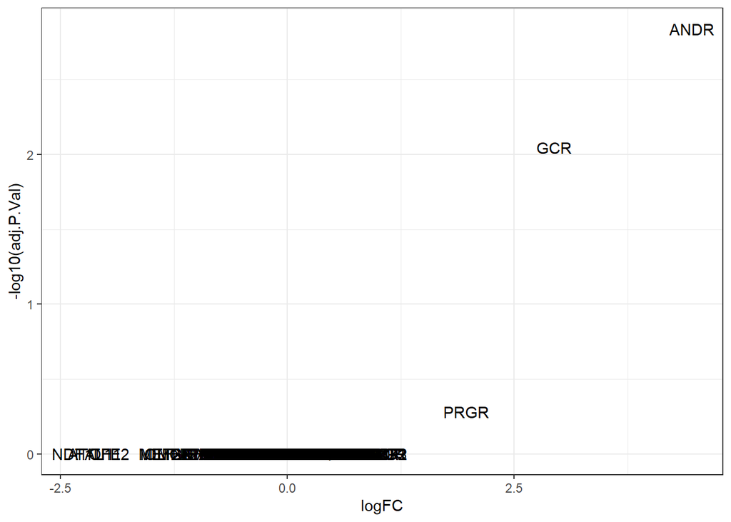

```r
#Add the normalized variablity z scores to the dev table
assays(dev)$norm <- scale(assays(dev)$z)
#Define the factors and organize so Control is base level
dev$condition <- factor(dev$condition)
dev$condition <- relevel(dev$condition, "Control")
#Set up the model matrix using condition as coefficient
mm_cond <- model.matrix(~dev$condition)

#Fit the linear model and get the stats using empirical Bayes moderation
fit_cond <- eBayes(lmFit(assays(dev)$norm, mm_cond))
#Extract the sorted list of the hits
res_cond <- as.data.frame(topTable(fit_cond, coef="dev$conditionFSS", number = Inf))

#Add the names and keep only the TF name
res_cond$Names <- gsub("\\_.*","",row.names(res_cond))
#Plot it
ggplot(res_cond, aes(x = logFC, y = -log10(adj.P.Val), label=Names)) +
  geom_text()+
  theme_bw()
```

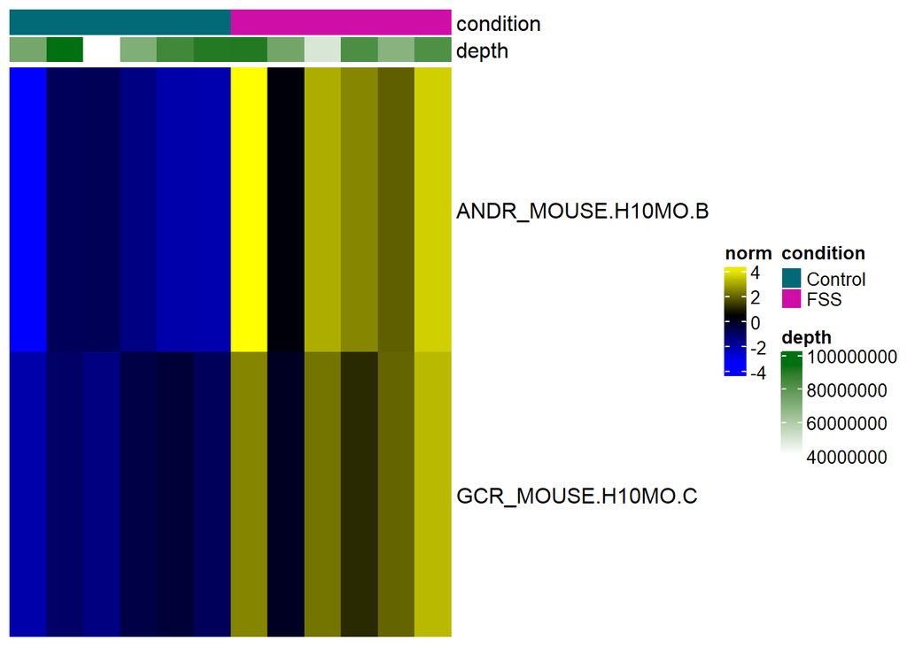

```r
#Report top 50 significant hits
top_cond <- head(res_cond[res_cond$adj.P.Val<=0.5,], 50)

#Plot the heatmap
sechm(dev, features = row.names(top_cond), assayName="norm", top_annotation = c("condition", "depth"))
```

Looking at both the volcano and the heatmap one can conclude that there are only two TFs with significantly different accessability between the control and force swim condition. This would indicate that such a treatment doesn’t elicit a wide response, atleast from an epigenomic perspective.

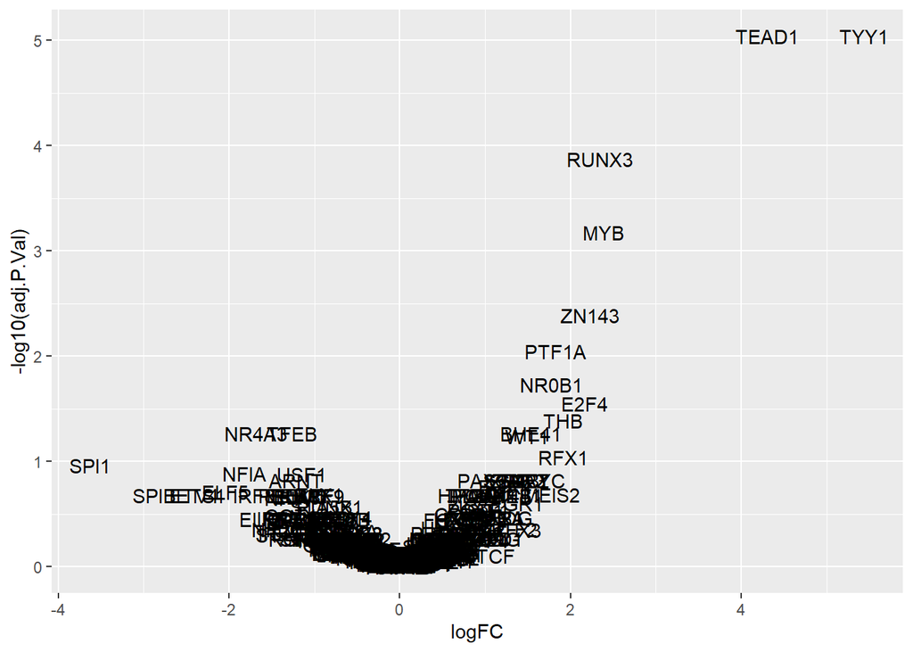

```r
#Add the normalized variablity z scores to the dev table
assays(dev)$norm <- scale(assays(dev)$z)
#Define the factors and organize so Male is base level
dev$sex <- factor(dev$sex)
dev$sex <- relevel(dev$sex, "Male")
#Set up the model matrix using sex as coefficient
mm_sex <- model.matrix(~dev$sex)

#Fit the linear model and get the stats using empirical Bayes moderation
fit_sex <- eBayes(lmFit(assays(dev)$norm, mm_sex))
#Extract the sorted list of the hits
res_sex <- as.data.frame(topTable(fit_sex, coef="dev$sexFemale", number = Inf))

#Add the names and keep only the TF name
res_sex$Names <-  gsub("\\_.*","",row.names(res_sex))
#Plot it
ggplot(res_sex, aes(logFC, -log10(adj.P.Val), label=Names)) + geom_text()
```

```r
#Report the top 50 significant hits
top_sex <- head(res_sex[res_sex$adj.P.Val<=0.5,], 50)
top_sex
```

```
##                          logFC      AveExpr         t      P.Value    adj.P.Val
## TYY1_MOUSE.H10MO.A   5.4386329 -0.230953502 10.114918 3.878434e-08 9.141053e-06
## TEAD1_MOUSE.H10MO.D  4.3055684 -0.156701863 10.038278 4.291574e-08 9.141053e-06
## RUNX3_MOUSE.H10MO.B  2.3408680 -0.132345320  7.894739 9.415987e-07 1.337070e-04
## MYB_MOUSE.H10MO.C    2.3885649 -0.277579791  6.743199 6.233753e-06 6.638947e-04
## ZN143_MOUSE.H10MO.D  2.2298102  0.072209041  5.605669 4.810711e-05 4.098726e-03
## PTF1A_MOUSE.H10MO.C  1.8303788 -0.196177392  5.096597 1.270142e-04 9.018006e-03
## NR0B1_MOUSE.H10MO.D  1.7786280 -0.022518533  4.654733 3.027021e-04 1.842159e-02
## E2F4_MOUSE.H10MO.C   2.1683916  0.105788164  4.373457 5.319167e-04 2.832456e-02
## THB_MOUSE.H10MO.C    1.9183343 -0.124112273  4.132175 8.675867e-04 4.106577e-02
## BHE41_MOUSE.H10MO.D  1.5404046 -0.252689005  3.907651 1.372926e-03 5.420518e-02
## TFEB_MOUSE.H10MO.C  -1.2573226  0.105154580 -3.895280 1.408209e-03 5.420518e-02
## NR4A3_MOUSE.H10MO.D -1.6783611  0.180281946 -3.855849 1.526906e-03 5.420518e-02
## WT1_MOUSE.H10MO.D    1.4972363 -0.166178637  3.788466 1.753646e-03 5.746564e-02
## RFX1_MOUSE.H10MO.C   1.9136323 -0.088889942  3.528154 2.997829e-03 9.121964e-02
## SPI1_MOUSE.H10MO.A  -3.6259190  0.505985748 -3.406514 3.852562e-03 1.094128e-01
## NFIA_MOUSE.H10MO.C  -1.8161790  0.158692942 -3.291673 4.881408e-03 1.299675e-01
## USF1_MOUSE.H10MO.A  -1.1482851  0.048849634 -3.252388 5.292712e-03 1.326291e-01
## ARNT_MOUSE.H10MO.B  -1.2123047  0.293396089 -3.139903 6.670189e-03 1.507926e-01
## PAX5_MOUSE.H10MO.S   0.9710205 -0.002712459  3.114171 7.032058e-03 1.507926e-01
## STAT3_MOUSE.H10MO.B  1.3458551  0.046790699  3.078955 7.558862e-03 1.507926e-01
## GLI2_MOUSE.H10MO.B   1.3559466 -0.348400401  3.063023 7.809796e-03 1.507926e-01
## SP3_MOUSE.H10MO.B    1.4233632 -0.010616040  3.055388 7.932942e-03 1.507926e-01
## MAZ_MOUSE.H10MO.D    1.5094271  0.027918730  3.011055 8.686623e-03 1.507926e-01
## NFYC_MOUSE.H10MO.B   1.6274073 -0.266148903  3.008586 8.730608e-03 1.507926e-01
## SP4_MOUSE.H10MO.D    1.2594293  0.010231259  3.001981 8.849333e-03 1.507926e-01
## E2F6_MOUSE.H10MO.A   1.2726461 -0.009318934  2.974279 9.364823e-03 1.534390e-01
## EGR4_MOUSE.H10MO.D   1.2358101 -0.140695419  2.898768 1.092400e-02 1.723564e-01
## ELF5_MOUSE.H10MO.D  -2.0360700  0.405789442 -2.825156 1.268672e-02 1.930194e-01
## MEIS2_MOUSE.H10MO.B  1.7777042 -0.441481881  2.764162 1.435434e-02 2.048034e-01
## TLX1_MOUSE.H10MO.D  -0.9414396  0.080817708 -2.761808 1.442277e-02 2.048034e-01
## CUX1_MOUSE.H10MO.C   1.0743147 -0.122580760  2.712994 1.591555e-02 2.095688e-01
## SPIB_MOUSE.H10MO.B  -2.8707422  0.416988245 -2.710226 1.600453e-02 2.095688e-01
## PLAG1_MOUSE.H10MO.S  0.9505018  0.033565255  2.701507 1.628798e-02 2.095688e-01
## RREB1_MOUSE.H10MO.D  1.2959275 -0.258973837  2.647104 1.816904e-02 2.095688e-01
## IRF8_MOUSE.H10MO.D  -1.7076058  0.400115646 -2.645198 1.823862e-02 2.095688e-01
## ETS1_MOUSE.H10MO.B  -2.3275584  0.351001247 -2.637205 1.853313e-02 2.095688e-01
## ERR1_MOUSE.H10MO.A  -1.2491655  0.237594743 -2.629246 1.883091e-02 2.095688e-01
## TFDP1_MOUSE.H10MO.D  0.9044396  0.049070777  2.626504 1.893459e-02 2.095688e-01
## HLTF_MOUSE.H10MO.D  -1.0512009  0.111229485 -2.610168 1.956359e-02 2.095688e-01
```

[output cut: 47 more lines]

```
## ETS1_MOUSE.H10MO.B  -3.7132855  ETS1
## ERR1_MOUSE.H10MO.A  -3.7282926  ERR1
## TFDP1_MOUSE.H10MO.D -3.7334605 TFDP1
## HLTF_MOUSE.H10MO.D  -3.7642006  HLTF
## ETV5_MOUSE.H10MO.D  -3.8246554  ETV5
## ZN148_MOUSE.H10MO.D -3.8386975 ZN148
## ETV4_MOUSE.H10MO.B  -3.8566206  ETV4
## PAX6_MOUSE.H10MO.D  -3.8647281  PAX6
## PRDM1_MOUSE.H10MO.A -3.8649728 PRDM1
## HMGA1_MOUSE.H10MO.D -3.8801873 HMGA1
## IRF9_MOUSE.H10MO.C  -3.9086387  IRF9
## ELK3_MOUSE.H10MO.D  -3.9486817  ELK3
## NFIA_MOUSE.H10MO.S  -3.9976427  NFIA
## EGR1_MOUSE.H10MO.A  -4.1227244  EGR1
## ZIC3_MOUSE.H10MO.C  -4.2175771  ZIC3
```

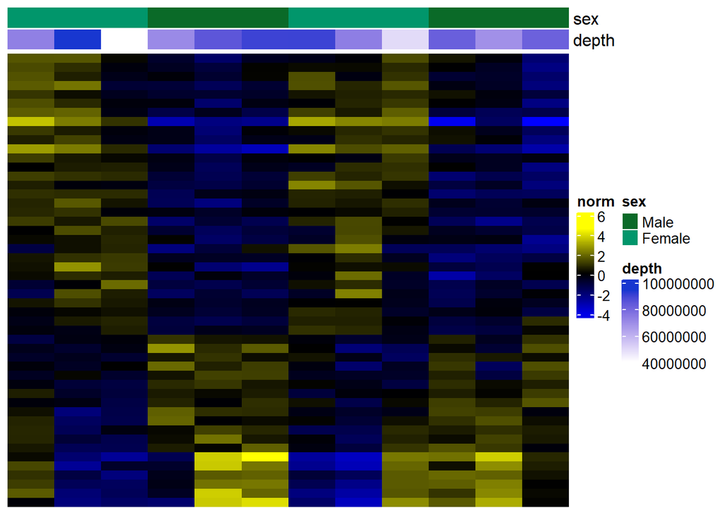

```r
#Plot the heatmap
sechm(dev, features = rownames(top_sex), assayName="norm", top_annotation = c("sex", "depth"))
```

In this case we can see a lot more variability, indicating there is a lot of variability in motif accessibility between the two sexes. This is especially exemplified when compared to the Control vs FSS analysis we did previously. Thus, there is a significant difference between the male and female hipocampus epigenomic behaviour, regardless of their condition (w.r.t. the conditions used in the given study)